# Quiz 4

## Question 1

Consider the space shuttle data `?shuttle` in the `MASS` library. Consider modeling the use of the autolander as the outcome (variable name `use`). Fit a logistic regression model with autolander (variable auto) use (labeled as “auto” 1) versus not (0) as predicted by wind sign (variable wind). Give the estimated odds ratio for autolander use comparing head winds, labeled as “head” in the variable headwind (numerator) to tail winds (denominator).

### Answer:

```r
library(dplyr)
library(MASS)
my.shuttle <- shuttle %>% mutate(use = factor(use, levels(use)[c(2,1)]))
head(my.shuttle)
```

```
##   stability error sign wind   magn vis  use
## 1     xstab    LX   pp head  Light  no auto
## 2     xstab    LX   pp head Medium  no auto
## 3     xstab    LX   pp head Strong  no auto
## 4     xstab    LX   pp tail  Light  no auto
## 5     xstab    LX   pp tail Medium  no auto
## 6     xstab    LX   pp tail Strong  no auto
```

```r
levels(my.shuttle$use)
```

```
## [1] "noauto" "auto"
```

```r
levels(my.shuttle$wind)
```

```
## [1] "head" "tail"
```

```r
mdl <- glm(use ~ wind, 'binomial', data=my.shuttle)
summary(mdl)
```

```
##
## Call:
## glm(formula = use ~ wind, family = "binomial", data = my.shuttle)
##
## Deviance Residuals:
##    Min      1Q  Median      3Q     Max
## -1.300  -1.286   1.060   1.073   1.073
##
## Coefficients:
##             Estimate Std. Error z value Pr(>|z|)
## (Intercept)  0.25131    0.17817   1.410    0.158
## windtail     0.03181    0.25224   0.126    0.900
##
## (Dispersion parameter for binomial family taken to be 1)
##
##     Null deviance: 350.36  on 255  degrees of freedom
## Residual deviance: 350.35  on 254  degrees of freedom
## AIC: 354.35
##
## Number of Fisher Scoring iterations: 4
```

```r
odds.head <- exp(mdl$coefficients[['(Intercept)']])
odds.tail <- exp(mdl$coefficients[['(Intercept)']] + mdl$coefficients[['windtail']])
odds.ratio <- odds.head/odds.tail
```

The odds ratio is 0.96869.

#### Cross check

```r
num.headwind <- nrow(shuttle[shuttle$wind == 'head',])
num.headwind.use <- nrow(shuttle[shuttle$wind == 'head' & shuttle$use == 'auto',])

num.tailwind <- nrow(shuttle[shuttle$wind == 'tail',])
num.tailwind.use <- nrow(shuttle[shuttle$wind == 'tail' & shuttle$use == 'auto',])

odds.head.check <- num.headwind.use/(num.headwind-num.headwind.use)
odds.tail.check <- num.tailwind.use/(num.tailwind-num.tailwind.use)
odds.head.check/odds.tail.check
```

```
## [1] 0.9686888
```

## Question 2

Consider the previous problem. Give the estimated odds ratio for autolander use comparing head winds (numerator) to tail winds (denominator) adjusting for wind strength from the variable magn.

### Answer:

```r
my.shuttle <- my.shuttle %>% mutate(magn = factor(magn, levels(magn)[c(1,2,4,3)]))
```

```r
mdl <- glm(use ~ wind + magn, 'binomial', data=my.shuttle)
summary(mdl)
```

```
##
## Call:
## glm(formula = use ~ wind + magn, family = "binomial", data = my.shuttle)
##
## Deviance Residuals:
##    Min      1Q  Median      3Q     Max
## -1.349  -1.321   1.015   1.040   1.184
##
## Coefficients:
##               Estimate Std. Error z value Pr(>|z|)
## (Intercept)  3.635e-01  2.841e-01   1.280    0.201
## windtail     3.201e-02  2.530e-01   0.127    0.899
## magnMedium   4.152e-16  3.599e-01   0.000    1.000
## magnStrong  -6.441e-02  3.590e-01  -0.179    0.858
## magnOut     -3.795e-01  3.568e-01  -1.064    0.287
##
## (Dispersion parameter for binomial family taken to be 1)
##
##     Null deviance: 350.36  on 255  degrees of freedom
## Residual deviance: 348.78  on 251  degrees of freedom
## AIC: 358.78
##
## Number of Fisher Scoring iterations: 4
```

```r
odds.head <- exp(mdl$coefficients[['(Intercept)']])
odds.tail <- exp(mdl$coefficients[['(Intercept)']] + mdl$coefficients[['windtail']])
odds.ratio <- odds.head/odds.tail
```

The odds ratio is 0.9685.

## Question 3

If you fit a logistic regression model to a binary variable, for example use of the autolander, then fit a logistic regression model for one minus the outcome (not using the autolander) what happens to the coefficients?

### Answer:

Flip sign.

#### Cross check

Recall the regression with auto = 2, and no auto = 1 gave.

```r
glm(use ~ wind, 'binomial', data=my.shuttle)$coef
```

```
## (Intercept)    windtail
##  0.25131443  0.03181183
```

```r
glm(use ~ wind, 'binomial', data=shuttle)$coef
```

```
## (Intercept)    windtail
## -0.25131443 -0.03181183
```

## Question 4

Consider the insect spray data `InsectSprays`. Fit a Poisson model using spray as a factor level. Report the estimated relative rate comapring spray A (numerator) to spray B (denominator).

### Answer:

```r
mdl <- glm(count ~ spray, 'poisson',
           data=InsectSprays[InsectSprays$spray == 'A' |
                               InsectSprays$spray == 'B',])
mdl$coef
```

```
## (Intercept)      sprayB
##  2.67414865  0.05588046
```

```r
rate.ratio <- exp(mdl$coefficients[1])/exp(mdl$coefficients[1] +
                                             mdl$coefficients[2])
```

The ratio of the rates is 0.94565.

## Question 5

Consider a Poisson glm with an offset, $t$. So, for example, a model of the form `glm(count ~ x + offset(t), family = poisson)` where `x` is a factor variable comparing a treatment (1) to a control (0) and `t` is the natural log of a monitoring time. What is impact of the coefficient for `x` if we fit the model `glm(count ~ x + offset(t2), family = poisson)` where `t2 <- log(10) + t`? In other words, what happens to the coefficients if we change the units of the offset variable. (Note, adding log(10) on the log scale is multiplying by 10 on the original scale.)

### Answer:

The coefficients should remain unchanged.

## Question 6

Consider the data

```r
x <- -5:5
y <- c(5.12, 3.93, 2.67, 1.87, 0.52, 0.08, 0.93, 2.05, 2.54, 3.87, 4.97)
```

Using a knot point at 0, fit a linear model that looks like a hockey stick with two lines meeting at x=0. Include an intercept term, x and the knot point term. What is the estimated slope of the line after 0?

### Answer:

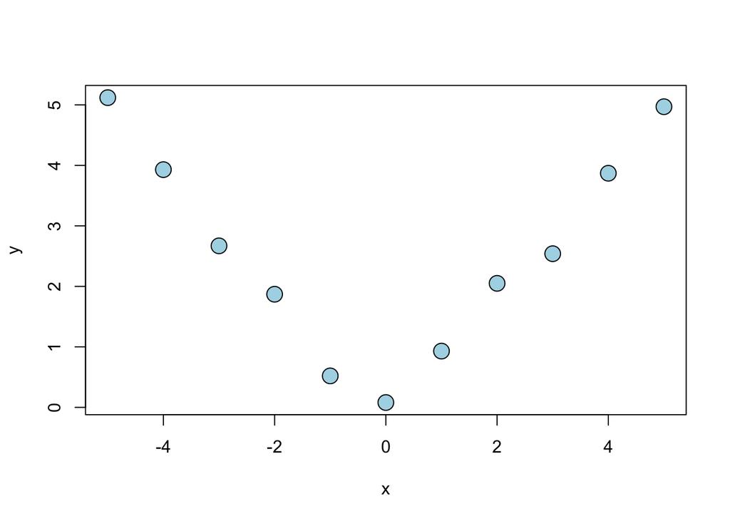

```r
plot(x, y, pch = 21, bg='lightblue', cex=2)
```

```r
spline = (x>0)*x
rhs <- cbind(x, spline)
fit <- lm(y ~ rhs)
summary(fit)
```

```
##
## Call:
## lm(formula = y ~ rhs)
##
## Residuals:
##      Min       1Q   Median       3Q      Max
## -0.32158 -0.10979  0.01595  0.14065  0.26258
##
## Coefficients:
##             Estimate Std. Error t value Pr(>|t|)
## (Intercept) -0.18258    0.13558  -1.347    0.215
## rhsx        -1.02416    0.04805 -21.313 2.47e-08 ***
## rhsspline    2.03723    0.08575  23.759 1.05e-08 ***
## ---
## Signif. codes:  0 '***' 0.001 '**' 0.01 '*' 0.05 '.' 0.1 ' ' 1
##
## Residual standard error: 0.2276 on 8 degrees of freedom
## Multiple R-squared:  0.986,  Adjusted R-squared:  0.9825
## F-statistic: 282.3 on 2 and 8 DF,  p-value: 3.812e-08
```

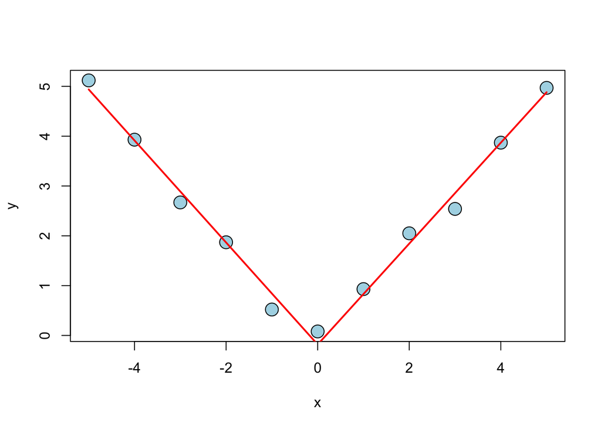

```r
yhat <- predict(fit)
plot(x, y, pch = 21, bg='lightblue', cex=2)
lines(x, yhat, col='red', lwd=2)
```

The slope after $x=0$ is 1.01307.